# Part II - Effet des variables sur le taux annuel effectif global (TAEG) et sur le Un score de risque personnalisé construit à partir des données historiques de Prosper

## Aperçu de l'enquête

Dans cette enquete j'ai voulu examiner les variables qui joue sur le taux annuel effectif global(TAEG) pour essayer de voir comment on attribut ce taux dans un pret l'accen a ete mis sur la duree le montant initiale la statue et le score alpha que la banque attribue au demandeur. J'ai voulu aussi examiner comment la banque fait pour donner des scores personnalisée au demandeur qui depends du montant de la duré du nombre de ligne de credit

## Aperçu de l'ensemble de données

Les banques receuillent beaucoup de données consernant leur utilsateur avant de leur delivré un pret. Dans ce context on va etudier un dataset contenant des informations sur les prets banquaires de 113937 personnes avec 81 variables dont:

1. LoanStatus : Status actuel du pret
2. BorrowerRate : Taux d'interet de l'emprunteur pour ce pret
3. StatedMonthlyIncome : Revenu mensuel declaré par l'emprunteur
4. Term: La durée du pret exprimée en mois
5. ProsperRating(Alpha) : La note Prosper attribuée au moment de la creation de la liste entre AA et HR
6. EmploymentStatus : Le statu d'emploi de l'emprunteur au moment ou il a créé la liste
7. LoanOriginalAmount : Montant initial du pret
8. ProsperScore : Un score de risque personnalisé construit a partir des données historiques de Prosper . Le score va de 1 a 10 ,10 etant le meilleur ou le plus faible score de risque
9. BorrowerAPR : le taux annuel effectif global(TAEG) de l'emprunteur pour le pret.
10. ListingCategory : La categorie de l'annonce que l'emprunteur a selectionnée lors de la publication de son annonce
11. EmploymentStatusDuration : La durée en mois du statut d'emploi au moment de la creation de la fiche
12. IsBorrowerHomeowner Un emprunteur sera classe comme proprietaire s'il a un pret hypothecaire dans son profil de credit ou s'il fournit des documents confirmant qu'il est proprietaire
13. Occupation : La profession choisie par l'emprunteur au moment ou il a créé la liste
14. CurrentCreditLines : Nombre de lignes de credit en cours au moment ou le profil de credit a ete etabli

etc.....

Pour notre etude on va se focaliser sur ses variables listé ici pour les besoin de notre analyse

[output not shown]

## Distribution du taux annuel effecti global(TAEG)

La distribution du taux annuel effectif global dans l'ensemble de donnée presente une tres large game de valeur allant d'environ 0 a 0.51 avec beaucoup de pic dont le plus haut est au environ de 0.35

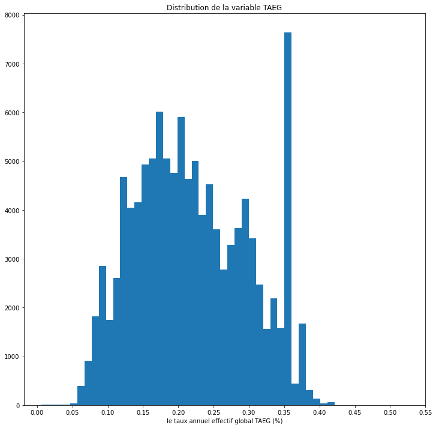

## Distribution du montant intiale du prets

Le montant initiale du pret est le montant du pret sans les taux elle ont une distribution asymetriques incliné vers la droite dont on a des valeurs trop grande a gauche . avec des valeur qui peut aller jusqu'a 35000$

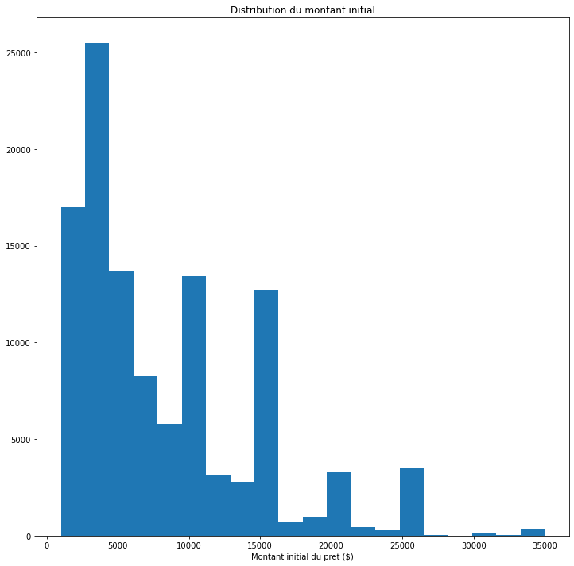

## Repartition de la durée des pret

La pluspart des demandeur de pret choisie entre 12 et 60mois pour rembouser leur pret. Et la plus part des personnes opte pour les 36 mois

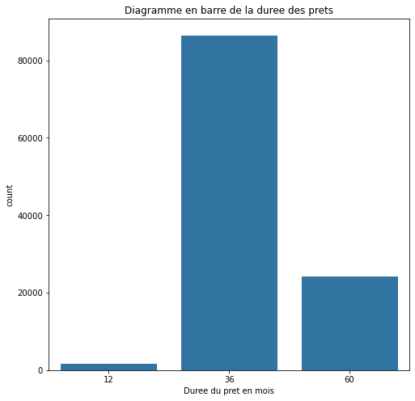

## Distribution ProsperRating (Alpha)

La banque attribue des score a chaque pret qui va de AA a HR et on voit que la classe C est la classe modale

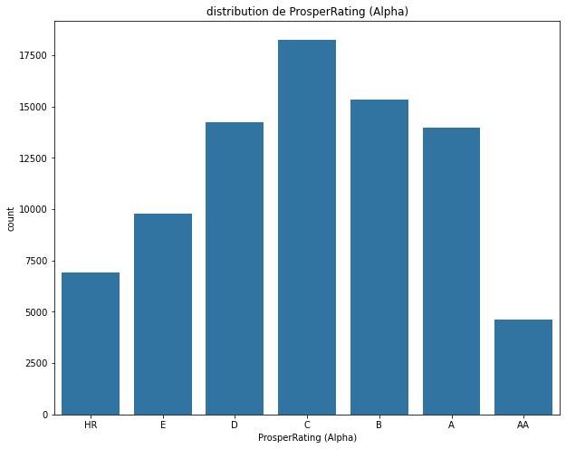

## Diagramme en Barre du score Personnalisé

Pour le score personnalisé la banque les attribues en fonction de l'historique . 4 est la classe modale

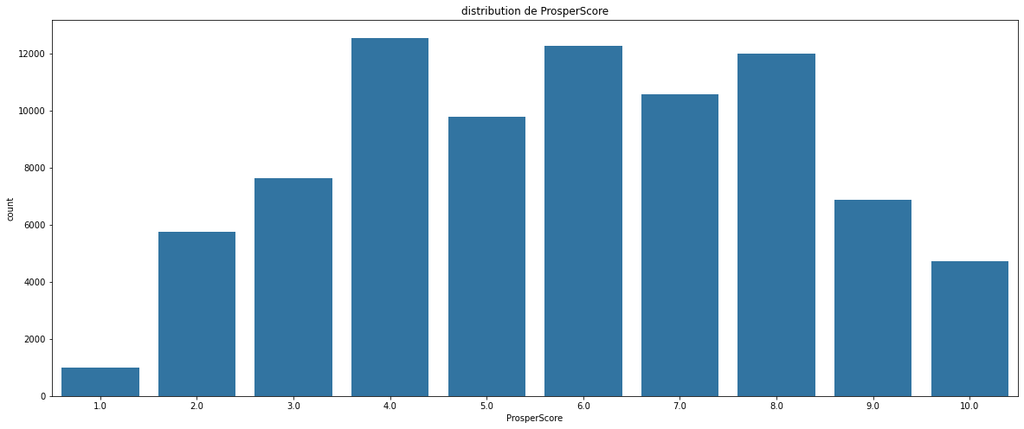

## Montant initial en fonction de la durée

Pour le montant initial du pret on a trouver que plus la durée augment on a des montant de pres plus eleve donc c'est deux variable on une correlation positive l'augmentation de l'un entraine l'augmentation de l'autre

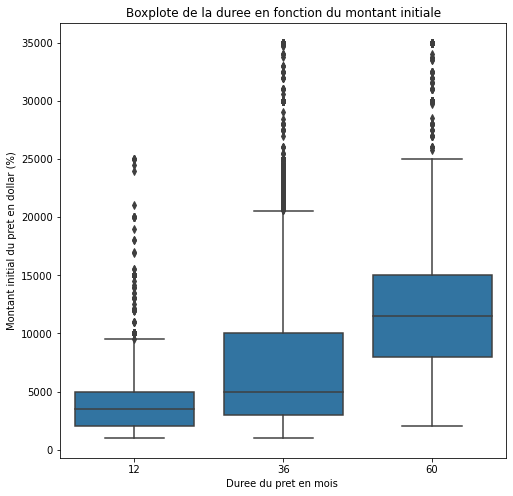

## TAEG en fonction du ProsperRating et de la duree pret

Les taux les plus faibles correspond au valeurs de ProsperRation de AA suivie de A et on vois que dans c'est deux modalités le taux augmente avec la durée donc la relation qu'on avait souligné en haut est confirmé par cette graphe

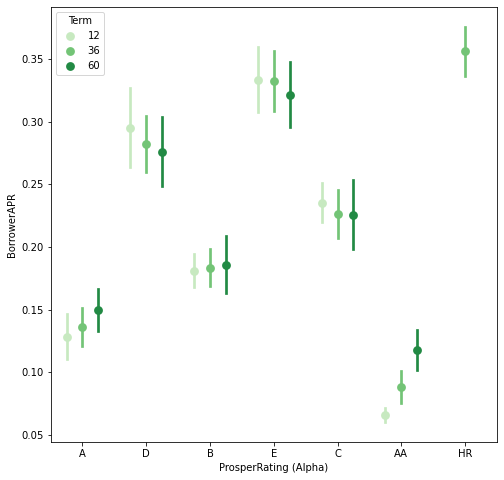

## Distribution du TAEG en fonction du montant initiale

Les etudes on confirmé la correlation negatif entre ces deux variable plus le montant est elevé plus le taux est faible et vis versa

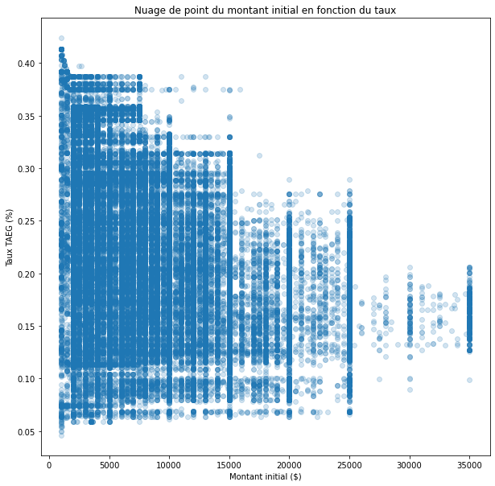